# TMDB box office prediction- Modeling(Xgboost, Neural Network, SVM, RandomForest )

# Create model

Here, we’ll use a sequential model with two densely connected hidden layers, and an output layer that returns a single, continuous value. The model building steps are wrapped in a function, build_model, since we’ll create a second model, later on.

```r
build_model <- function() {

  model <- keras_model_sequential() %>%
    layer_dense(units = 64, activation = "relu",
                input_shape = dim(train_data)[2]) %>%
    layer_dense(units = 64, activation = "relu") %>%
    layer_dense(units = 1)

  model %>% compile(
    loss = "mse",
    optimizer = optimizer_rmsprop(),
    metrics = list("mean_absolute_error")
  )

  model
}

model <- build_model()
model %>% summary()
```

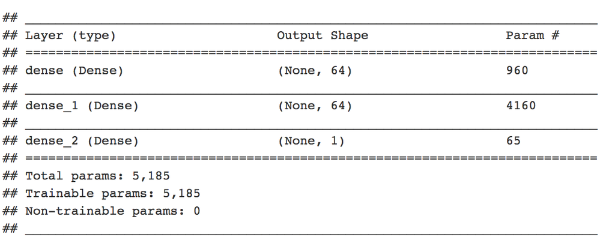

The model is trained for 500 epochs, recording training and validation accuracy in a keras_training_history object. We also show how to use a custom callback, replacing the default training output by a single dot per epoch.

```r
 # Display training progress by printing a single dot for each completed epoch.
print_dot_callback <- callback_lambda(
  on_epoch_end = function(epoch, logs) {
    if (epoch %% 80 == 0) cat("\n")
    cat(".")
  }
)

epochs <- 500

# Fit the model and store training stats
history <- model %>% fit(
  train_data,
  train_label_log,
  epochs = epochs,
  validation_split = 0.2,
  verbose = 0,
  callbacks = list(print_dot_callback)
)
```

Now, we visualize the model’s training progress using the metrics stored in the history variable. We want to use this data to determine how long to train before the model stops making progress.

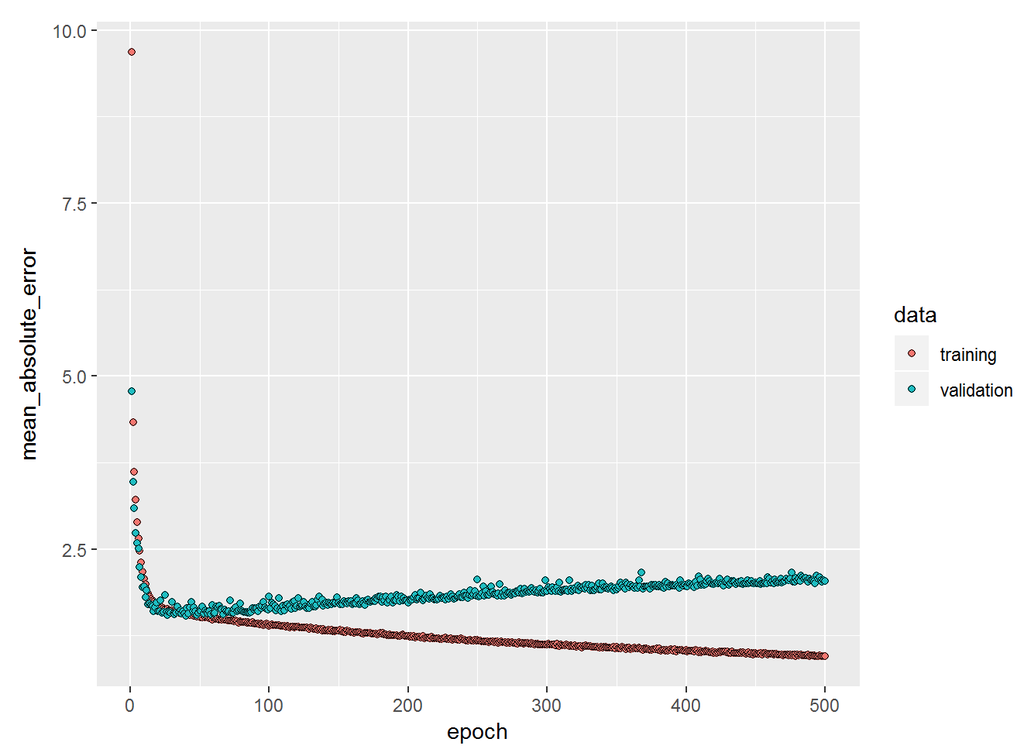

```r
library(ggplot2)

plot(history, metrics = "mean_absolute_error", smooth = FALSE)
```

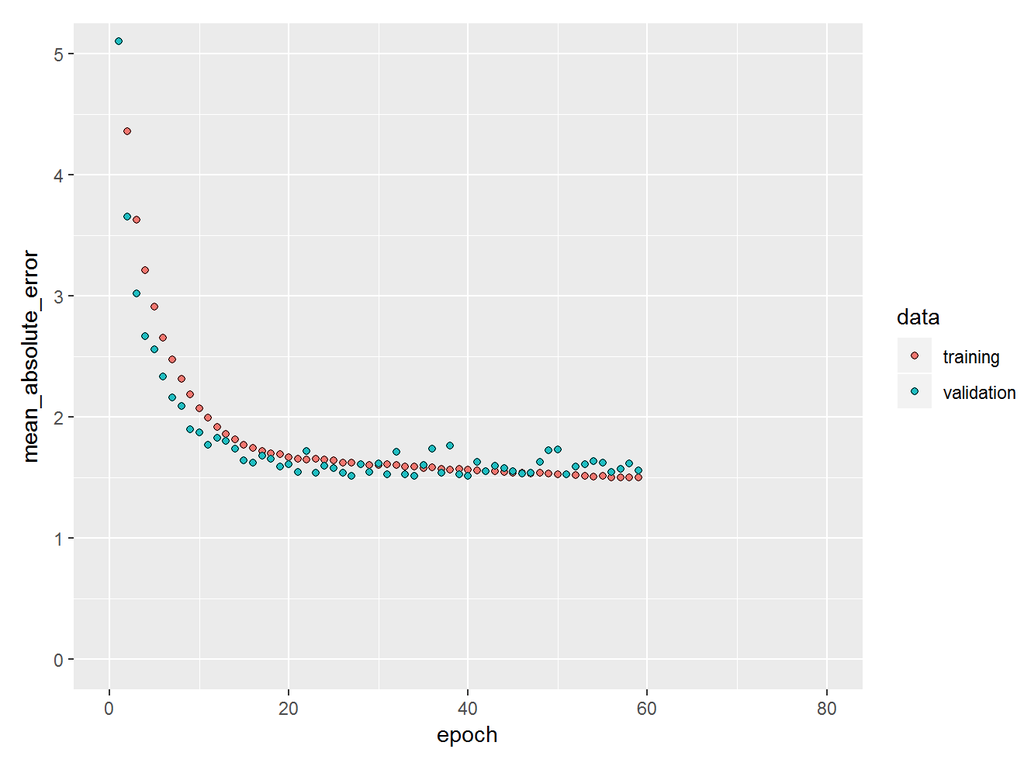

```r
early_stop <- callback_early_stopping(monitor = "val_loss", patience = 20)

model <- build_model()
history <- model %>% fit(
  train_data,
  train_label_log,
  epochs = epochs,
  validation_split = 0.2,
  verbose = 0,
  callbacks = list(early_stop, print_dot_callback)
)

plot(history, metrics = "mean_absolute_error", smooth = FALSE)+ coord_cartesian(xlim = c(0,80), ylim = c(0,5))
```

Here we got out keras model with its predictions.

```r
test_predictions_keras <- model %>% predict(test_data)
pred.test_nolog_keras=exp(test_predictions_keras)-1
```

## Deep learning model: Nnet

Since these models are highly parameterized and thus will tend to overfit the training data. Cross-validation is therefore critical to make sure that the predictive performance of the neural network model is adequate.

```r
train_cluster = read.csv("train_clean2.csv")
test_cluster = read.csv("test_clean2.csv")
```

```r
#train_orgin <- read.csv("train_clean.csv")
#train_labels <- train_orgin[,"revenue"]
nnet_variable <- c("popularity", "runtime", "numberOfGenres","numberOfcasts", "numberOfcrews", "numberOfcompanies", "numberOfcoun", "numberOflang", "numberOfKeywords", "overviewLengthInWords", "log.budget", "overviewLengthInSentence", "p1","n1")
nnet_train_data <- train_cluster[,nnet_variable]
train_label_log<- train_cluster$log.revenue
nnet_train_data <- cbind(nnet_train_data, train_label_log)
nnet_test_data <- test_cluster[,nnet_variable]
```

I compared the result from scale the train data and without scaling. Due the text mining techiques, our current data is pretty sparse, so scaling is not giving us a good result. And I found out that the more maxit (more iterations), the better result we could have, however, we need to tune the model to avoid overfitting problems. Another observation is that if we change decay into a very small number, it’s better than defalut 0.

```r
#nnet_train_data<- scale(nnet_train_data)
#use the means and sd to normalize test set
#col_means_train<- attr(nnet_train_data, "scaled:center")
#col_stddevs_train <- attr(nnet_train_data, "scaled:scale")
#nnet_test_data <- scale(nnet_test_data, center = col_means_train, scale = col_stddevs_train)

#nnet_test_data<- scale(nnet_test_data)

#nnet(x= train_model, y = train_labels, size = 5, maxit = 50 )

model.nnet<- nnet(train_label_log~., data= nnet_train_data, linout= TRUE, size = 15, skip= TRUE,MaxNWts=10000, trace=FALSE, maxit=2000,decay = 5e-4)

nnet_pred<- predict(model.nnet, nnet_test_data)
pred.test_nolog_nnet=exp(nnet_pred)-1

#kaggle score: 2.33533
```

## SVM

SVM is a supervised machine learning algorithm which can be used for classification or regression problems. It uses a technique called the kernel trick to transform your data and then based on these transformations it finds an optimal boundary between the possible outputs. For the svm model:

There is also a cost parameter which we can change to avoid overfitting

```r
library(rpart)

svm.model <- svm(train_label_log~., data= nnet_train_data, cost = 1000, gamma = 0.00001)
pred.svm <- predict(svm.model, newdata = nnet_test_data)
pred.test_nolog_svm=exp(pred.svm)-1

# 2.49479
```

```r
svm_tune <- tune.svm(train_label_log~., data = nnet_train_data, gamma =  0.000005:0.00001, cost = 1100:1105)
plot(svm_tune)
```

[output not shown]

SVM have become a popular technique in flexible modelling, but there are some drawbacks, though: SVMs scale rather badly with the data size due to the quadratic optimization algorithm and the kernel transformation. Furthermore, the correct choice of kernel parameters is crucial for obtaining good results, which practically means that an extensive search must be conducted on the parameter space before results can be trusted, and this often complicates the task.

```r
test<- read.csv("test_clean2.csv", stringsAsFactors = FALSE, na.strings = c("","#N/A","[]"))
# setwd('D:/personal/columbia university/AA method 2/final project/tmdb-box-office-prediction')
# test_withID=read.csv("test_clean_with text.csv", stringsAsFactors = FALSE)
#
# submission1= data.frame(id = test_withID$id, revenue = pred1.test_nolog)
# write.csv(submission1, 'submission1.csv',row.names = F)
submissionFile = data.frame(id = test$id, revenue = pred.test_nolog_nnet)
write.csv(submissionFile, 'submission_nnet10.csv',row.names = F)
```

```r
library(data.table)
library(DT)
model.comb <- data.table("Model name"= c( "XGboost","XGboost+Clustering","Keras","Nnet", "SVM", "Random Forest"), "Test score" = c( 2.18, 2.20,2.21, 2.33, 2.49,2.83))
datatable(model.comb)
```

[output not shown]